# Exploration of the SINDy method and PySINDy package

#### DTU, August 2021

### Import packages and libraries

```python
import matplotlib.pyplot as plt
from mpl_toolkits.mplot3d import Axes3D
from matplotlib.cm import rainbow
import numpy as np
from scipy.integrate import odeint
from scipy.io import loadmat
import os
import pandas as pd
from sklearn import linear_model

import pysindy as ps

from explore_sindy_added_functions import plot_model
path_data = '../data/dmi/time_series'
path_fig_sindy = './figures/sindy'
df_thy_26_30 = pd.read_csv(os.path.join(path_data,'df_thyborøn_26to30.csv'),index_col='date_observed')
df_thy_26_30.sort_index(inplace=True)
```

#### *This notebook is primarily based on work from*

```
Brunton, Steven L., Joshua L. Proctor, and J. Nathan Kutz. "Discovering governing equations from data by sparse identification of nonlinear dynamical systems." Proceedings of the national academy of sciences 113.15 (2016): 3932-3937.
```

*and*

```
de Silva, Brian M., et al. "Pysindy: a python package for the sparse identification of nonlinear dynamics from data." arXiv preprint arXiv:2004.08424 (2020).
```

#### *Purpose of the notebook*

This notebook will introduce the theoretical foundation of SINDy and explore how it works on three simulated dynamical systems. Then we test the performance of the model on real data using wind data from Thyborøn provided by [DMI](https://confluence.govcloud.dk/display/FDAPI/Danish+Meteorological+Institute+-+Open+Data). The purpose of the notebook is to give some intuition about how we can apply SINDy and possibly think of ways to improve and extend SINDy for later studies.

# Sparse identification of nonlinear dynamics - SINDy

Consider a system with states $\mathbf{x}\in \mathbb{R}^n$ and derivatives $\dot{\mathbf{x}}\in \mathbb{R}^n$ sampled at times $t_1, t_2,...,t_m$ s.t.

$$ \begin{align*} \mathbf{x}(t) &= \begin{bmatrix} x_1(t), x_2(t),...,x_n(t) \end{bmatrix}^\intercal \\ \dot{\mathbf{x}}(t) &= \begin{bmatrix} \dot{x}_1(t), \dot{x}_2(t),...,\dot{x}_n(t) \end{bmatrix}^\intercal \end{align*} $$

construct two matrices $\mathbf{X}\in M_{m\times n}(\mathbb{R})$ and $\dot{\mathbf{X}}\in M_{m\times n}(\mathbb{R})$

$$ \begin{align*} \mathbf{X}&=\left[\begin{array}{c} \mathbf{x}^{T}\left(t_{1}\right) \\ \mathbf{x}^{T}\left(t_{2}\right) \\ \vdots \\ \mathbf{x}^{T}\left(t_{m}\right) \end{array}\right]=\left[\begin{array}{cccc} x_{1}\left(t_{1}\right) & x_{2}\left(t_{1}\right) & \cdots & x_{n}\left(t_{1}\right) \\ x_{1}\left(t_{2}\right) & x_{2}\left(t_{2}\right) & \cdots & x_{n}\left(t_{2}\right) \\ \vdots & \vdots & \ddots & \vdots \\ x_{1}\left(t_{m}\right) & x_{2}\left(t_{m}\right) & \cdots & x_{n}\left(t_{m}\right) \end{array}\right] \end{align*} $$$$ \begin{align*} \dot{\mathbf{X}}&=\left[\begin{array}{c} \dot{\mathrm{x}}^{T}\left(t_{1}\right) \\ \dot{\mathrm{x}}^{T}\left(t_{2}\right) \\ \vdots \\ \dot{\mathrm{x}}^{T}\left(t_{m}\right) \end{array}\right]=\left[\begin{array}{cccc} \dot{x}_{1}\left(t_{1}\right) & \dot{x}_{2}\left(t_{1}\right) & \cdots & \dot{x}_{n}\left(t_{1}\right) \\ \dot{x}_{1}\left(t_{2}\right) & \dot{x}_{2}\left(t_{2}\right) & \cdots & \dot{x}_{n}\left(t_{2}\right) \\ \vdots & \vdots & \ddots & \vdots \\ \dot{x}_{1}\left(t_{m}\right) & \dot{x}_{2}\left(t_{m}\right) & \cdots & \dot{x}_{n}\left(t_{m}\right) \end{array}\right] \end{align*} $$

Construct an augmented library $\Theta(\mathbf{X})\in M_{m\times p}(\mathbb{R})$ where p is the number of new created columns of mappings in $\Theta$:

$$ \begin{align*} \Theta(\mathbf{X})=\left[\begin{array}{ccccccccc} \mid & & \mid & \mid & & \mid & \mid & \mid & \mid & \\ 1 & \mathbf{X} & \mathbf{X}^{P_{2}} & \mathbf{X}^{P_{3}} & \cdots & \sin (\mathbf{X}) & \cos (\mathbf{X}) & \sin (2 \mathbf{X}) & \cos (2 \mathbf{X}) & \cdots \\ \mid & \mid & \mid & \mid & & \mid & \mid & \mid & \mid & \end{array}\right] \end{align*} $$

where the polynomials in the above are defined as

$$ \begin{align*} \mathbf{X}^{P_{2}}=\left[\begin{array}{ccccccc} x_{1}^{2}\left(t_{1}\right) & x_{1}\left(t_{1}\right) x_{2}\left(t_{1}\right) & \cdots & x_{2}^{2}\left(t_{1}\right) & x_{2}\left(t_{1}\right) x_{3}\left(t_{1}\right) & \cdots & x_{n}^{2}\left(t_{1}\right) \\ x_{1}^{2}\left(t_{2}\right) & x_{1}\left(t_{2}\right) x_{2}\left(t_{2}\right) & \cdots & x_{2}^{2}\left(t_{2}\right) & x_{2}\left(t_{2}\right) x_{3}\left(t_{2}\right) & \cdots & x_{n}^{2}\left(t_{2}\right) \\ \vdots & \vdots & \ddots & \vdots & \vdots & \ddots & \vdots \\ x_{1}^{2}\left(t_{m}\right) & x_{1}\left(t_{m}\right) x_{2}\left(t_{m}\right) & \cdots & x_{2}^{2}\left(t_{m}\right) & x_{2}\left(t_{m}\right) x_{3}\left(t_{m}\right) & \cdots & x_{n}^{2}\left(t_{m}\right) \end{array}\right] \end{align*} $$

Introduce $\xi_i=\begin{bmatrix}\xi_i^{(1)} & \xi_i^{(2)} & ... & \xi_1^{(p)}\end{bmatrix}\in\mathbb{R}^p$ and $\mathbf{\Xi}\in M_{p\times n}\left(\mathbb{R}\right)$ s.t.

$$ \begin{align*} \mathbf{\Xi} = \begin{bmatrix}\mathbf{\xi}_1 & \mathbf{\xi}_2 & ... & \mathbf{\xi}_n\end{bmatrix}^\intercal \end{align*} $$

$\xi_i$ determines the sparse vector of coefficients for the i'th state hence we write

$$ \dot{\mathbf{X}}=\Theta(\mathbf{X}) \Xi $$

we can now solve for $\Theta$ using sparse regression to get a sparse representation for our dynamical system.

## Worked example

In this worked example, we will construct optimization problem and give concrete examples on how to solve the sparse regression problem

### Find the sparse representation

To find the sparse representation, we could use LASSO with a regularization parameter $\lambda$. We first define the problem s.t. we can easily see how the problem can be solved using the LASSO regression analysis.

Consider the $k$'th row of $\dot{\mathbf{X}}$ where $\dot{\mathbf{x}}_k=\begin{bmatrix}\dot{x}_{1}\left(t_{1}\right) & \dot{x}_{2}\left(t_{1}\right) & \cdots & \dot{x}_{n}\left(t_{1}\right) \end{bmatrix}^\intercal$ then we can write

$$ \begin{align} \dot{\mathbf{x}} = \Theta(\mathbf{x^\intercal}) \xi_k \end{align} $$

s.t. $\Theta(\mathbf{x^\intercal})\in \mathbb{R}^{mp}$ i.e. a vector of all the library of function applied on $\mathbf{x_k}$. We want to determine the sparse vector of coefficients $\mathbf{\xi}_k^*$ in

$$ \begin{align} \xi^* = \arg \min_\xi \vert\vert \dot{\mathbf{x}}- \Theta(\mathbf{x^\intercal}) \xi_k \vert \vert_2^2 + \lambda \vert\vert \xi\vert\vert_1 \end{align} $$

where $\vert\vert \cdot \vert \vert_2^2$ is the $\ell_2$-norm and $\vert\vert \cdot \vert \vert_1$ is the $\ell_1$-norm. Imposing the $\ell_1$-norm in the problem ensures $\xi^*$ will be sparse for $\lambda>0$ and as we increase $\lambda$, we increase the sparsity of the solution.

Multiple solutions exist for finding $\xi^*$ e.g. *cyclic coordinate descent* or *Lars*. These will either fix all $\beta_{i\neq k}$ and update $\beta_k$ following some update rule or in multiple steps update the value of $\beta_k$ by looking at the correlation with the residuals. They encounter the same problems with scaling because they consider each input feature at each iteration which makes them computationally expensive.

Therefore, we can use the much simpler sequential thresholded least-squares algorithm. Here we find an OLS solution for $\mathbf{\Xi}$, then set all coefficients to zero, if they are below some threshold $\lambda$. Now calculate the OLS solution again and threshold the coefficients. Repeat until convergence.

# Application

We will consider the same three examples as we considered for the hierarchical deep learning time steppers:

- hyperbolic system
- cubic oscillator
- Van der Pol oscillator

We will choose the same set of parameters as for the HiTs. We will see if the SINDy algorithm manages to recover the representation and coefficients of the known systems.

Next, we consider wind speed and direction from Thyborøn to see if SINDy can describe these systems well. To improve the ability for SINDy to recognize the system, we will also apply a fast Fourier transformation to denoise the data. Everything is described and implemented in the DMI notebook.

### Feature library and optimization algorithm

For the three examples of simulated data, we will use the polynomial library with order up to 3. For the data from Thyborøn, we will also include the Fourier library hence we will introduce $\sin$ and $\cos$ to our library as briefly mentioned in the introduction to the library matrix $\Theta(\mathbf{X})$.

In the simulate examples, we will use sequential thresholded least-squares algorithm with $\lambda=0.02$ or $\lambda=0.05$. For the wind data, we will also try the Lasso and more elaborate methods like the Sparse Relaxed Regularized Regression, SR3 algorithm which is described and recommended in the [PySINDy documentation](https://pysindy.readthedocs.io/en/latest/).

## Case studies

The following section will take more the format of a notebook to demonstrate how the package works for the simulated case studies.

### Hyperbolic system

We now consider the hyperbolic system

\begin{split} \dot{x} &= \mu x \\ \dot{y} &= \lambda(y-x^2) \end{split}

With $\mu = -0.05$ and $\lambda = -1.0$.

```python
def hyperbolic(x,t):
    return np.array([mu*x[0],
                     lam*(x[1]-x[0]**2)])

mu = -0.05
lam = -1.0
dt = 0.01
t_train_hyp = np.arange(0,50,dt)
x0_train_hyp = np.array([2,0])
x_train_hyp = odeint(hyperbolic, x0_train_hyp, t_train_hyp)
```

we define the polynomial order, the threshold and pass these to the PySINDy module. We use the library sequential thresholded least squares algorithm `ps.STLSQ` and the polynomial library `ps.PolynomialLibrary`.

```python
poly_order = 3
threshold = 0.02

model_hyp = ps.SINDy(
    optimizer=ps.STLSQ(threshold=threshold),
    feature_library=ps.PolynomialLibrary(degree=poly_order),
)
model_hyp.fit(x_train_hyp, t=dt)
model_hyp.print()
```

```
x0' = -0.050 x0
x1' = -1.000 x1 + 1.000 x0^2
```

Here we see that SINDy correctly identifies the representation and coefficients of the system. Graphically, we can see this when we simulate using the found model with the initial conditions of the training set:

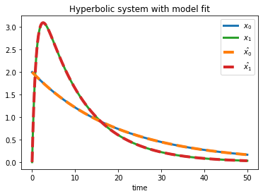

```python
x_sim_hyp = model_hyp.simulate(x0_train_hyp, t_train_hyp)

fig_labels_str = ['x_0','x_1']
fig_labels = [f'${{{label}}}$' for label in fig_labels_str]
fig_model_labels = [f'$\hat{{{label}}}$' for label in fig_labels_str]


colors = ['#1f77b4', '#2ca02c','#ff7f0e', '#d62728']
plt.gca().set_prop_cycle(color=colors)

plt.plot(t_train_hyp
         , x_train_hyp
         , linewidth = 3.0
         , label = fig_labels)
plt.plot(t_train_hyp
         , x_sim_hyp
         , linewidth=4.0
         , ls = "dashed"
         , label=fig_model_labels)
plt.title("Hyperbolic system with model fit")
plt.xlabel("time")
plt.legend()
```

It is just on target.

### The Cubic oscillator

Consider the system

\begin{split} \dot{x} &= -0.1x^3 + 2y^3 \\ \dot{y} &= -2x^3 - 0.1y^3 \end{split}

we save the data points at $\Delta t=0.01$ equally spaced data points.

```python
def cubic_rhs(x,t):
    return np.array([-0.1*x[0]**3 + 2*x[1]**3,
                     -2*x[0]**3 - 0.1*x[1]**3])
dt = 0.01
t_train_cub = np.arange(0,50,dt)
x0_train_cub = np.array([2,0])
x_train_cub = odeint(cubic_rhs, x0_train_cub, t_train_cub)
```

We define the model and use sequential least-squares algorithm

```python
poly_order = 3
threshold = 0.05

model_cub = ps.SINDy(
    optimizer=ps.STLSQ(threshold=threshold),
    feature_library=ps.PolynomialLibrary(degree=poly_order),
)
model_cub.fit(x_train_cub, t=dt)
model_cub.print()
```

```
x0' = -0.100 x0^3 + 1.999 x1^3
x1' = -1.999 x0^3 + -0.100 x1^3
```

We see that the representation is correct and the values of the coefficients are also correct with neglectable discrepancies. The simulation proves this:

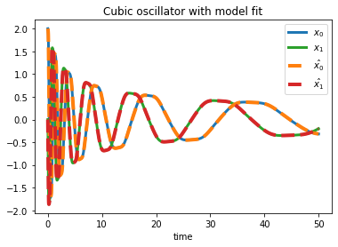

SINDy performs really well on the Cubic oscillator as well.

# Van der Pol oscillator

\begin{split} \dot{x} &= y \\ \dot{y} &= \mu(1-x^2)y - x \end{split}

where $\mu=2.0$

```python
def van_der_pol_rhs(x,t):
    return np.array([x[1],
                     mu*(1-x[0]**2)*x[1]-x[0]])
mu = 2.0
dt = 0.01
t_train_vdp = np.arange(0,50,dt)
x0_train_vdp = np.array([1,0])
x_train_vdp = odeint(van_der_pol_rhs, x0_train_vdp, t_train_vdp)
```

```python
poly_order = 3
threshold = 0.02

model_vdp = ps.SINDy(
    optimizer=ps.STLSQ(threshold=threshold),
    feature_library=ps.PolynomialLibrary(degree=poly_order),
)
model_vdp.fit(x_train_vdp, t=dt)
model_vdp.print()
```

```
x0' = 1.000 x1
x1' = -1.000 x0 + 1.999 x1 + -1.999 x0^2 x1
```

Collecting the terms, we again see that the SINDy algorithm correctly identifies the system and the coefficients. The graphical result is:

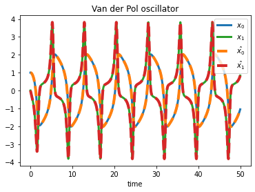

Graphically, we also see that SINDy managed to capture the dynamics of the system.

We conclude that the SINDy algorithm performs remarkably well on all the case studies considered with simulated data. It is both able to correctly identify the representation and coefficients of the systems considered.

# SINDy on wind data from Thyborøn 26th to 30th of July 2021

In the following, we will try to predict wind speed and direction from a weather station at Thyborøn. We will transform the data into new coordinates to better work understand and visually work with wind speed and direction. To denoise the signal, we will also use a fast Fourier transformation. Many of the choices are based on experiments in a separate, more pragmatic notebook. Multiple stations and periods were considered, however, Thyborøn was chosen as there were few missing values, and data from 2021 was interesting.

### Transformation of wind speed and direction

To better assess the relationship, we make a transformation of the data. To do this, we first transform the direction of the wind. From DMI it is given from 0-360 degrees, however, North is at 360 degrees which is not intuitive for graphical representations. As suggested in [this post](http://colaweb.gmu.edu/dev/clim301/lectures/wind/wind-uv), we rotate the wind direction 270 degrees. Let $wwd$ be the degrees given from DMI, then we obtain the rotated direction $md$:

$$ \begin{align*} md = 270 − wwd \end{align*} $$

now we convert these to radians to obtain the following wind directions over time.

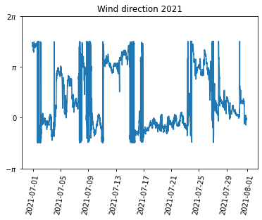

We now transform the wind speed, $ws$ and wind direction, $\theta$, into a new set of coordinates $(u,v)$:

$$ \begin{align*} u &= ws \cdot \cos \theta\\ v &= ws \cdot \sin \theta \end{align*} $$

With the new transformation, we can represent the wind as a vector with a magnitude corresponding to the wind speed and direction as that of the wind.

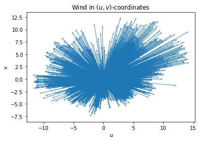

We can also make it comparable with the time series and make it a gif:

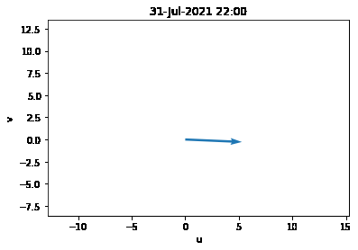

This gives a more intuitive understanding of which direction the wind is blowing and the wind speed.

To display the distribution of the wind speed and direction over time, we can create a 2D histogram:

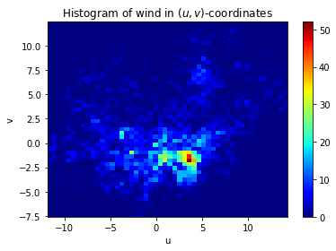

hence we see that the wind comes from the northwest, however, when the wind comes from the southwest, the wind can be very strong.

The time series in the transformed coordinates can also be explored:

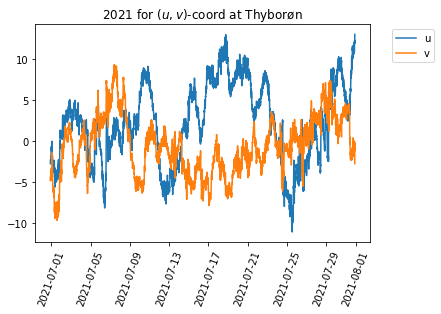

all of these plots tell that the wind fluctuates across time hence it would be hard for SINDy to find specific formulas that proscribe the dynamics for the entire period. Therefore, we will consider a shorter time interval

### Limit data to recent observations

We will focus on the most recent observations. Consult the plots with the time series from 2021 to see that in the most recent period, there seems to be a trend. The period of interest is depicted below:

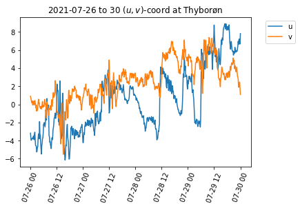

We will train SINDy with an increasing amount of data for us to follow the training pattern and see which amount of data is optimal for the algorithm to converge. This also gives a way to potentially cross-validate the found models.

Therefore, we will use this slide window approach. Visually the procedure is well encapsulated in the figure below

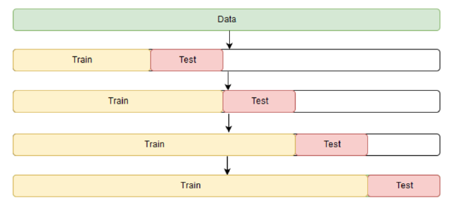

The link to the figure can be found [here](https://stats.stackexchange.com/q/268847).

The model representation and coefficients vary when we vary the libraries, the chosen optimization algorithm, the parameters of the optimization algorithm, and the time interval. Therefore, the following section is just one of many tested combinations. The results are not impressive, however, it gives an intuition about what we can expect of this type of model.

```python
train_26 = df_thy_26_30.loc[:'2021-07-27',:].to_numpy()
test_27 = df_thy_26_30.loc['2021-07-27':'2021-07-28',:].to_numpy()
```

We will allow polynomials up to order 5 and include the Fourier library with `n_frequenies=2` which means we include e.g. $\cos(u)$, $\cos(2x)$, $\sin(u)$, $\sin(2x)$ as described in the introduction.

```python
poly_order = 5
poly_library = ps.PolynomialLibrary(degree=poly_order)
fourier_library = ps.FourierLibrary(n_frequencies=2)
combined_library = poly_library + fourier_library

threshold = 0.05
optim = ps.STLSQ(threshold=threshold)
#optim = ps.SR3(threshold=0.1, nu=1)

model_26 = ps.SINDy(optimizer=optim
                    , feature_library=combined_library
                    , discrete_time=True
                    , feature_names=df_thy_26_30.loc[:'2021-07-27',:].columns
)

model_26.fit(train_26)
model_26.print()
```

```
u[k+1] = -0.291 1 + 0.900 u[k] + 0.358 v[k] + 0.054 u[k] v[k] + -0.160 sin(1 u[k]) + -0.397 sin(1 v[k]) + 0.218 cos(1 v[k]) + -0.072 sin(2 u[k]) + -0.178 cos(2 v[k])
v[k+1] = 1.093 v[k] + 0.112 u[k] v[k] + 0.107 sin(1 u[k]) + -0.241 cos(1 u[k]) + -0.084 cos(1 v[k]) + -0.149 cos(2 u[k]) + 0.144 sin(2 v[k]) + -0.136 cos(2 v[k])
```

The complexity of the model has now increased dramatically, however, we will discover that the results are not impressive for the train data:

```python
train_sim_26 = model_26.simulate(train_26[0,:],t=train_26.shape[0])
```

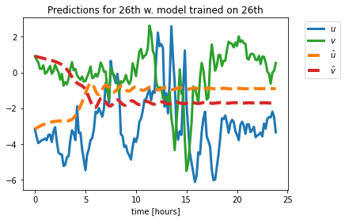

```python
plot_model(train_26,train_sim_26, 'Predictions for 26th w. model trained on 26th')
```

and neither for the test data:

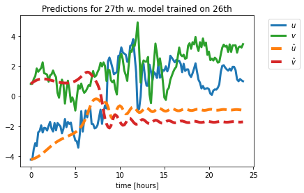

```python
test_sim_27 = model_26.simulate(test_27[0,:],t=test_27.shape[0])
plot_model(test_27,test_sim_27, 'Predictions for 27th w. model trained on 26th')
```

As we see, the model structure is very complex but it both fits the train data and test data very poorly.

### Train on the 26th and 27th - test on 28th

We will now see if the model performance increases if we include more data

```python
train_26_27 = df_thy_26_30.loc[:'2021-07-28',:].to_numpy()
test_28 = df_thy_26_30.loc['2021-07-28':'2021-07-29',:].to_numpy()
```

```python
poly_order = 6
poly_library = ps.PolynomialLibrary(degree=poly_order)
fourier_library = ps.FourierLibrary()
combined_library = poly_library + fourier_library

threshold = 0.05
optim = ps.STLSQ(threshold=threshold)
#optim = ps.SR3(threshold=0.1, nu=1)

model_26_27 = ps.SINDy(optimizer=optim
                    , feature_library=combined_library
                    , discrete_time=True
                    , feature_names=df_thy_26_30.loc[:'2021-07-27',:].columns
)

model_26_27.fit(train_26_27)
model_26_27.print()
```

```
u[k+1] = 0.943 u[k] + 0.064 v[k] + 0.118 cos(1 u[k])
v[k+1] = 0.914 v[k] + 0.125 sin(1 u[k]) + -0.161 cos(1 u[k]) + -0.072 cos(1 v[k])
```

```python
train_sim_26_27 = model_26_27.simulate(train_26_27[0,:],t=train_26_27.shape[0])
```

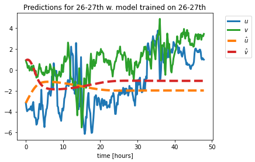

```python
plot_model(train_26_27,train_sim_26_27, 'Predictions for 26-27th w. model trained on 26-27th')
```

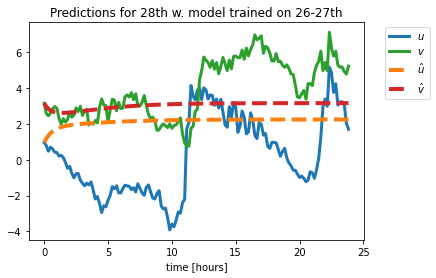

```python
test_sim_28 = model_26_27.simulate(test_28[0,:],t=test_28.shape[0])
plot_model(test_28,test_sim_28, 'Predictions for 28th w. model trained on 26-27th')
```

For now, the increased number of training points do not make SINDy find a model.  
The final experiment is to include one more day for training and see if this improves anything:

### Train on 26-28th - test on 29

```python
train_26_27_28 = df_thy_26_30.loc[:'2021-07-29',:].to_numpy()
test_29 = df_thy_26_30.loc['2021-07-29':'2021-07-30',:].to_numpy()

poly_order = 6
poly_library = ps.PolynomialLibrary(degree=poly_order)
fourier_library = ps.FourierLibrary()
combined_library = poly_library + fourier_library

threshold = 0.05
optim = ps.STLSQ(threshold=threshold)
#optim = ps.SR3(threshold=0.1, nu=1)

model_26_27_28 = ps.SINDy(optimizer=optim
                    , feature_library=combined_library
                    , discrete_time=True
                    , feature_names=df_thy_26_30.loc[:'2021-07-27',:].columns
)

model_26_27_28.fit(train_26_27_28)
model_26_27_28.print()
```

```
u[k+1] = -0.172 1 + 0.931 u[k] + 0.063 v[k] + 0.074 cos(1 v[k])
v[k+1] = 0.050 1 + 0.968 v[k] + -0.097 cos(1 u[k])
```

The model has similarities with the found model before but no representation seems to dominate

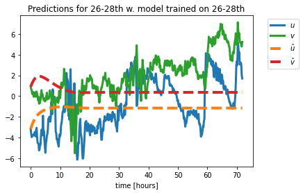

```python
train_sim_26_27_28 = model_26_27_28.simulate(train_26_27_28[0,:],t=train_26_27_28.shape[0])
plot_model(train_26_27_28,train_sim_26_27_28, 'Predictions for 26-28th w. model trained on 26-28th')
```

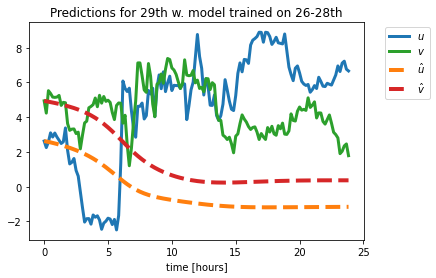

```python
test_sim_29 = model_26_27_28.simulate(test_29[0,:],t=test_29.shape[0])
plot_model(test_29,test_sim_29, 'Predictions for 29th w. model trained on 26-28th')
```

When we include more data, we do not see any huge improvement in the trained model hence for this dataset, we should probably focus on a shorter time horizon both for test and train data. A way to improve model performance could be to denoise the signal which we will do in this the next section.

### Fast Fourier transform of the data

When we do the fast Fourier transform, we take out only the components with high powers. Consider the frequency power spectrum for $u$:

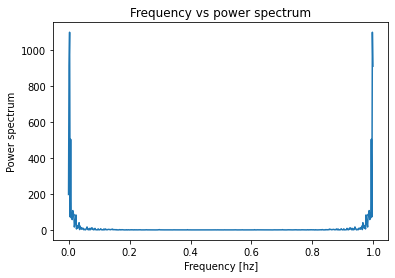

now we can denoise the signal by thresholding components with powers above e.g. 600. For we $v$ we thresholded at 500 which can be seen in the fast Fourier notebook. The result is

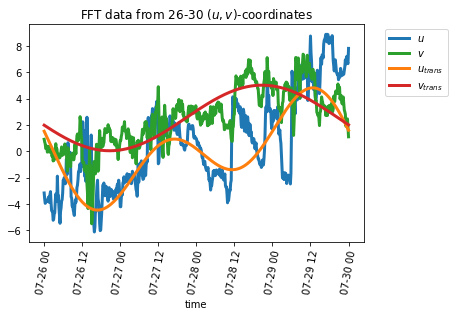

The first components do not contain all the fluctuations which now makes the found models only an approximation to the real data. However, the series is more smooth which could potentially help SINDy find the governing equations of the system.  
We will again try the window sliding framework to see how the model changes when more data is included for training. The following is one example of the many different outputs obtained when changing the parameters, the optimization algorithm, and the library. Notice that we use the `SR3` algorithm for optimization now. This is because the sequential thresholded least-squares algorithm sometimes performs quite poorly.

```python
path_data = '../data/dmi/time_series'
df_thy_26_30_fft = pd.read_csv(os.path.join(path_data,'df_thyborøn_26to30_fft.csv'),index_col='date_observed')
df_thy_26_30_fft.sort_index(inplace=True)
```

```python
train_26_fft = df_thy_26_30_fft.loc[:'2021-07-27',:].to_numpy()
test_27_fft = df_thy_26_30_fft.loc['2021-07-27':'2021-07-28',:].to_numpy()

poly_order = 5
poly_library = ps.PolynomialLibrary(degree=poly_order)
fourier_library = ps.FourierLibrary(n_frequencies=2)
combined_library = poly_library + fourier_library

threshold = 0.05
#optim = ps.STLSQ(threshold=threshold)
optim = ps.SR3(threshold=0.03
               , nu=1.2
               , max_iter=20000)

model_26_fft = ps.SINDy(optimizer=optim
                    , feature_library=combined_library
                    , discrete_time=True
                    , feature_names=df_thy_26_30.loc[:'2021-07-27',:].columns
)

model_26_fft.fit(train_26_fft)
model_26_fft.print()
```

```
u[k+1] = -1.066 1 + 0.899 u[k] + 2.941 v[k] + -0.016 u[k]^2 + 0.138 u[k] v[k] + -0.015 u[k] v[k]^2 + -0.273 v[k]^3 + 0.003 u[k] v[k]^3 + -0.045 v[k]^4 + 0.002 u[k] v[k]^4 + 0.013 v[k]^5 + -2.457 sin(1 v[k]) + 0.972 cos(1 v[k]) + 0.002 sin(2 v[k]) + -0.011 cos(2 v[k])
v[k+1] = 0.042 1 + 0.010 u[k] + 0.504 v[k] + -0.023 v[k]^2 + 0.119 v[k]^3 + -0.021 v[k]^4 + 0.437 sin(1 v[k]) + 0.011 sin(2 v[k])
```

The found model is very complex because we used a low threshold but it fits the training data really well

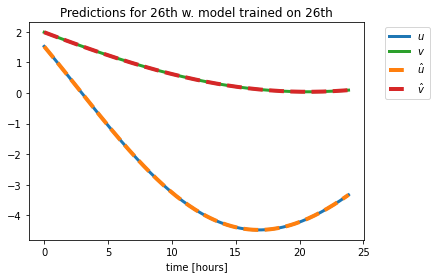

```python
train_sim_26_fft = model_26_fft.simulate(train_26_fft[0,:],t=train_26_fft.shape[0])
plot_model(train_26_fft,train_sim_26_fft, 'Predictions for 26th w. model trained on 26th')
```

This model could be very prone to overfitting and therefore we test the model on the coming day:

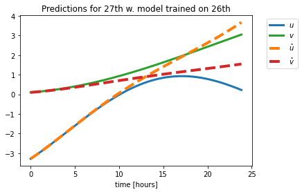

```python
test_sim_27 = model_26_fft.simulate(test_27_fft[0,:],t=test_27_fft.shape[0])
plot_model(test_27_fft,test_sim_27, 'Predictions for 27th w. model trained on 26th')
```

We see that it performs reasonbly within the first 5 hours of the prediction. We now try to include more data

### Train on the 26-27th

```python
train_26_27_fft = df_thy_26_30_fft.loc[:'2021-07-28',:].to_numpy()
test_28_fft = df_thy_26_30_fft.loc['2021-07-28':'2021-07-29',:].to_numpy()
```

```python
poly_order = 2
poly_library = ps.PolynomialLibrary(degree=poly_order)
fourier_library = ps.FourierLibrary(n_frequencies=2)
combined_library = poly_library + fourier_library

#threshold = 0.049
#optim = ps.STLSQ(threshold=threshold)
optim = ps.SR3(threshold=0.31
               , nu=1.5
               , max_iter=100000)


model_26_27_fft = ps.SINDy(optimizer=optim
                    , feature_library=combined_library
                    , discrete_time=True
                    , feature_names=df_thy_26_30.loc[:'2021-07-27',:].columns
)
model_26_27_fft.fit(train_26_27_fft)
model_26_27_fft.print()
```

```
u[k+1] = 0.999 u[k]
v[k+1] = 1.688 sin(1 v[k])
```

A quite simple model comes out which is also due to the high threshold we use here

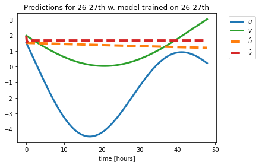

```python
train_sim_26_27_fft = model_26_27_fft.simulate(train_26_27_fft[0,:], t=train_26_27_fft.shape[0])
plot_model(train_26_27_fft,train_sim_26_27_fft, 'Predictions for 26-27th w. model trained on 26-27th')
```

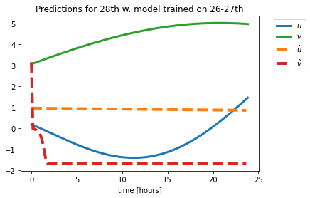

```python
test_sim_28_fft = model_26_27_fft.simulate(test_28[0,:],t=test_28.shape[0]-1)
plot_model(test_28_fft,test_sim_28_fft, 'Predictions for 28th w. model trained on 26-27th')
```

The model above was found with rigorous testing of different combinations of the libraries and the optimization algorithm with different parameters. Often, the model would be a very complex system of equations with terms that exploded when $t$ was increased s.t. the model couldn't show predictions on the period it was trained due to numerical overflow. The model building procedure needs some improvements

### Ideas for improvements of SINDy

- Use a formal model selection procedure e.g. use cross-validation to tune the parameters of the optimization algorithm and the libraries. Here one could also consider a fixed time-horizon for the cross-validation method which is illustrated in the figures below. This could improve our model as we saw that it struggles to find any representation when presented to a long training time horizon.

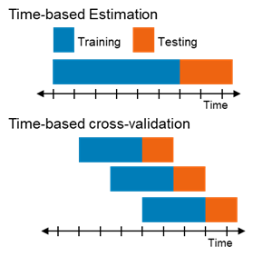

*Figure is form [this article](https://towardsdatascience.com/time-based-cross-validation-d259b13d42b8)*

- Reconsider the framework and how to tune the hyperparameters. The sparse vector of coefficients is $\xi_i=\begin{bmatrix}\xi_i^{(1)} & \xi_i^{(2)} & ... & \xi_1^{(p)}\end{bmatrix}\in\mathbb{R}^p$. Within each training time-horizon try different hyperparameters and save the $\xi_i$ for each set of parameters. Make the $\xi_i$ binary s.t. $$\begin{align}\xi_i^{(j)}=\begin{cases}0, &\text{if }\xi_i^{(j)}=0 \\ 1, &\text{if } \xi_i^{(j)}\neq0 \end{cases}\end{align}$$ and take out the most frequent terms across all hyperparameter settings and finetune the parameters for the most frequent representation. To ensure the best representation is chosen, one could weight the binary vector by the score of the tested set of hyperparameters on training data. In this way, we would only use terms that occur across many parameter settings.
- A rigorous test for stationarity could be performed and a box-cox transformation could also be relevant to potentially stabilize the variance. We used FFT to denoise the system, however, alternative denoise methods and algorithms could also be applied. A kernel function could also be relevant to locally weight the inputs to its neighbors and thereby remove random fluctuations and allow SINDy to find a representation more easily using the kernel estimates.

### Discussion of methods used:

- Since we use SINDy in discrete time, there is hardly any difference between SINDy and LASSO regression on the feature library matrix and response variable. Here one could make use of already implemented LASSO recursive feature selection algorithms as an alternative to the sequential least-squares algorithm to find the most important features i.e the best representation.
- We never formally make any consideration on the range of the time frame we use to train. Here one could utilize ideas from time series e.g. lag dependence functions and partial lag dependence functions to identify the appropriate length to train on. If no non-linear relationships exist for the entire length of the time frame, we should shorten the range. This could also be a method to choose the optimal fix time-horizon span in the proposed cross-validation method above.